# Atividade 04 - Segregation test

Author

Vitória Bizão Murakami

# Segregation test in maize RIL population

Using the provided dataset, describe the hypothesis test and perform the segregation tests in each marker. Using five randomly picked markers, plot the theoretical distribution and the corresponding significance level and p-value.

## Segregação 1:2:1

Vamos testar que os marcadores com valores 0, 1 e 2 do `data.frame` segue uma segregação de 1:2:1, em que 0 ele não tem nenhuma dose daquele alelo naquele marcador, 1 tem uma dose e 2 tem duas doses.

```r
# Função para análise por marcador
analise_marcador <- function(nome_col) {
  dados <- df_sub[[nome_col]]

  obs_tab <- table(factor(dados, levels = c(0, 1, 2))) # Genótipos observados (0, 1, 2)
  n_total <- sum(obs_tab)

  prob_esp <- c(0.25, 0.5, 0.25)  # Frequência esperada
  freq_esp <- prob_esp * n_total  # Genótipos esperados

  teste <- chisq.test(obs_tab, p = prob_esp) # Teste Qui-Quadrado
  p_val <- teste$p.value # p-valor

  # Agrupando os resultados em um df
  df_plot <- data.frame(Genotipo = factor(c(0, 1, 2), levels = c(0, 1, 2)),
                        Observado = as.numeric(obs_tab) / n_total,
                        Esperado = prob_esp,
                        Marcador = nome_col,
                        P_Value = p_val)

  return(df_plot)
}

#debug(analise_marcador)
#(analise_marcador("PZA00986.1"))
#undebug(analise_marcador)

# Para os 5 marcadores
resultados <- bind_rows(lapply(cols_sorteadas, analise_marcador))
# View(resultados)

datatable(resultados,
          colnames = c("Genótipo", "Observado", "Esperado", "Marcador", "p-valor"),
          caption = "Segregação 1:1",
          options = list(pageLength = 4,
                         lengthMenu = c(3, 10, 20),
                         dom = 'tp')) %>%
  formatRound(columns = c('Observado', 'Esperado', 'P_Value'), digits = 3)
```

|  | Genótipo | Observado | Esperado | Marcador | p-valor |
| --- | --- | --- | --- | --- | --- |
| 1 | 0 | 0.4838709677419355 | 0.25 | PZA00986.1 | 1.079923102486747e-26 |
| 2 | 1 | 0.1021505376344086 | 0.5 | PZA00986.1 | 1.079923102486747e-26 |
| 3 | 2 | 0.4139784946236559 | 0.25 | PZA00986.1 | 1.079923102486747e-26 |
| 4 | 0 | 0.4594594594594595 | 0.25 | PZA00740.3 | 3.318157406641019e-28 |
| 5 | 1 | 0.08648648648648649 | 0.5 | PZA00740.3 | 3.318157406641019e-28 |
| 6 | 2 | 0.4540540540540541 | 0.25 | PZA00740.3 | 3.318157406641019e-28 |
| 7 | 0 | 0.5 | 0.25 | PZA02654.3 | 1.15712148044486e-29 |
| 8 | 1 | 0.08064516129032258 | 0.5 | PZA02654.3 | 1.15712148044486e-29 |
| 9 | 2 | 0.4193548387096774 | 0.25 | PZA02654.3 | 1.15712148044486e-29 |
| 10 | 0 | 0.4814814814814815 | 0.25 | PZD00038.2 | 4.087520584818504e-35 |

[output cut: 5 more lines]

Observando o teste de Qui-quadrado observamos que os marcadores tem p-valor que tende a 0, e que provavelmente não é essa a segregação que ele segue. Mas, vamos olhar o gráfico de frequência das doses marcadores observadas contra as esperadas caso a segregração fosse 1:2:1.

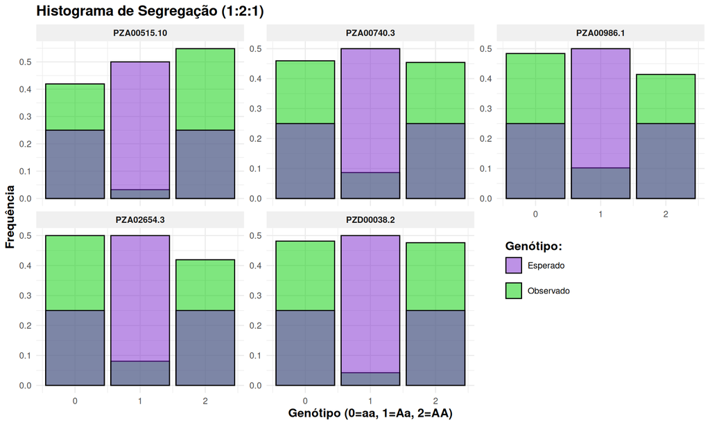

```r
# Oraganização dados
resultados_long <- resultados %>%
  pivot_longer(cols = c(Observado, Esperado),
               names_to = "Tipo",
               values_to = "Frequencia") %>%
  mutate(Genotipo_num = as.numeric(as.character(Genotipo)))
# View(resultados_long)

# Gráfico
ggplot(resultados_long, aes(x = Genotipo_num, y = Frequencia, fill = Tipo)) +
  geom_histogram(stat = "identity",
                 position = "identity",
                 alpha = 0.5,
                 color = "black",
                 binwidth = 0.6) +
  facet_wrap(~ Marcador, scales = "free_y") +
  scale_x_continuous(breaks = c(0, 1, 2)) +
  scale_y_continuous(breaks = seq(0, 1, 0.1)) +
  scale_fill_manual(values = c("Observado" = "green3",
                               "Esperado" = "purple3")) +
  labs(title = "Histograma de Segregação (1:2:1)",
       y = "Frequência",
       x = "Genótipo (0=aa, 1=Aa, 2=AA)",
       fill = "Genótipo:") +
  theme_minimal() +
  theme(legend.position = "inside",
        legend.position.inside = c(0.75, 0.35),
        legend.key.spacing.y = unit(0.3, "cm"),
        strip.background = element_rect(fill = "#f0f0f0", color = NA),
        strip.text = element_text(face = "bold"),
        title = element_text(size = 12, face = "bold"))
```

Os gráficos também corroboram para que a proporção de segregação não seja 1:2:1. Então, podemos criar a hipótese de que essa população de RILs já está avançada o bastante para estar em homozigose. Dessa forma, a segregação que eu espero é de 1:1. Vamos testar-la:

## Segregação 1:1

```r
df_sub[df_sub == 1] = NA

# Função para análise por marcador
analise_marcador <- function(nome_col) {
  dados <- df_sub[[nome_col]]

  obs_tab <- table(factor(dados, levels = c(0, 2))) # Genótipos observados (0, 1, 2)
  n_total <- sum(obs_tab)

  prob_esp <- c(0.5, 0.5)  # Frequência esperada
  freq_esp <- prob_esp * n_total  # Genótipos esperados

  teste <- chisq.test(obs_tab, p = prob_esp) # Teste Qui-Quadrado
  p_val <- teste$p.value # p-valor

  # Agrupando os resultados em um df
  df_plot <- data.frame(Genotipo = factor(c(0, 2), levels = c(0, 2)),
                        Observado = as.numeric(obs_tab) / n_total,
                        Esperado = prob_esp,
                        Marcador = nome_col,
                        P_Value = p_val)

  return(df_plot)
}

# Para os 5 marcadores
resultados11 <- bind_rows(lapply(cols_sorteadas, analise_marcador))
# View(resultados)

datatable(resultados11,
          colnames = c("Genótipo", "Observado", "Esperado", "Marcador", "p-valor"),
          caption = "Segregação 1:1",
          options = list(pageLength = 4,
                         lengthMenu = c(3, 10, 20),
                         dom = 'tp')) %>%
  formatRound(columns = c('Observado', 'Esperado', 'P_Value'), digits = 3)
```

|  | Genótipo | Observado | Esperado | Marcador | p-valor |
| --- | --- | --- | --- | --- | --- |
| 1 | 0 | 0.5389221556886228 | 0.5 | PZA00986.1 | 0.3144299041012076 |
| 2 | 2 | 0.4610778443113773 | 0.5 | PZA00986.1 | 0.3144299041012076 |
| 3 | 0 | 0.5029585798816568 | 0.5 | PZA00740.3 | 0.9386847392067751 |
| 4 | 2 | 0.4970414201183432 | 0.5 | PZA00740.3 | 0.9386847392067751 |
| 5 | 0 | 0.543859649122807 | 0.5 | PZA02654.3 | 0.2513491088102227 |
| 6 | 2 | 0.456140350877193 | 0.5 | PZA02654.3 | 0.2513491088102227 |
| 7 | 0 | 0.5027624309392266 | 0.5 | PZD00038.2 | 0.9407482722760154 |
| 8 | 2 | 0.4972375690607735 | 0.5 | PZD00038.2 | 0.9407482722760154 |
| 9 | 0 | 0.4333333333333333 | 0.5 | PZA00515.10 | 0.07363827012030277 |
| 10 | 2 | 0.5666666666666667 | 0.5 | PZA00515.10 | 0.07363827012030277 |

A partir dos p-valores calculados eu não rejeito a hipótese de segregação de 1:1, pois as diferenças entre as frequências observadas e esperadas são pequenas o suficiente para serem explicadas pelo acaso. Vamos olhar também o histograma dos dados observados e esperados.

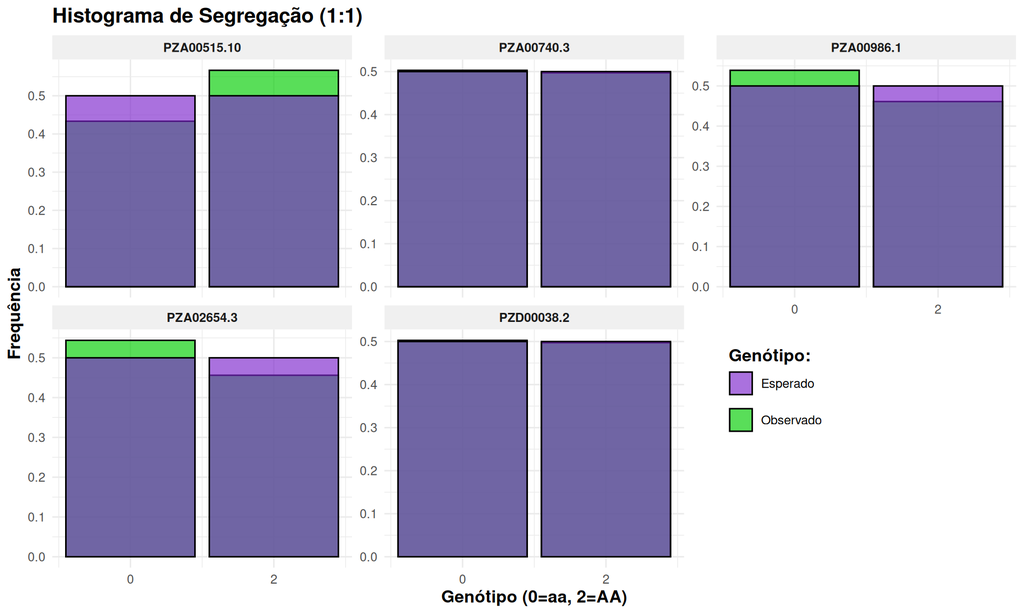

```r
# Oraganização dados
resultados_long11 <- resultados11 %>%
  pivot_longer(cols = c(Observado, Esperado),
               names_to = "Tipo",
               values_to = "Frequencia") %>%
  mutate(Genotipo_num = as.numeric(as.character(Genotipo)))
# View(resultados_long)

# Gráfico
ggplot(resultados_long11, aes(x = Genotipo_num, y = Frequencia, fill = Tipo)) +
  geom_histogram(stat = "identity",
                 position = "identity",
                 alpha = 0.65,
                 color = "black",
                 binwidth = 0.6) +
  facet_wrap(~ Marcador, scales = "free_y") +
  scale_x_continuous(breaks = c(0, 2)) +
  scale_y_continuous(breaks = seq(0, 1, 0.1)) +
  scale_fill_manual(values = c("Observado" = "green3",
                               "Esperado" = "purple3")) +
  labs(title = "Histograma de Segregação (1:1)",
       y = "Frequência",
       x = "Genótipo (0=aa, 2=AA)",
       fill = "Genótipo:") +
  theme_minimal() +
  theme(legend.position = "inside",
        legend.position.inside = c(0.75, 0.35),
        legend.key.spacing.y = unit(0.3, "cm"),
        strip.background = element_rect(fill = "#f0f0f0", color = NA),
        strip.text = element_text(face = "bold"),
        title = element_text(size = 12, face = "bold"))
```

Aqui podemos ver que o observado se comporta mais com o que eu espero de uma população de RILs.